# Economics in R - Data of Macroeconomics

Hyundo Im

May 30 2017

# Measuring the Value of Economic Activity: Gross Domestic Product

**Gross Domestic Product**, or GDP, is considered the best measure of performances of the economy. There are two ways to view GDP: 1. view GDP as the total income of everyone in the economy 2. the total expenditure on the economy’s output of goods and services.

## Income, Expenditure, and the Circular Flow

- What is a flow?
- Economists distinguish two kinds of quantity variables
  - Stock: a quantity measured at a given point in time
  - Flow: a quantity measured per unit of time.
- Examples of Stock and Flow
  - A person’s wealth is a tcok and his income and expenditure are flows
  - The number of unemployed people is a stock, the number of people losing their jobs is a flow
  - The amount of capital in the economy is a stock, the amount of investment is a flow

## Rules for Computing GDP

Definition of GDP again: *the market value of all final goods and services produced within an economy in a given period of time.*

#### Used goods are not included in GDP

#### Inventories that are produced in one year are only considered the part of GDP of that year no matter when it is sold

#### Intermediate goods and value added are not included in GDP

#### Housing services and other imputations are complicated…

## Real GDP and Nominal GDP

Nominal GDP: the value of goods and services measured at current prices. Real GDP: the value of good and services measured using a constant set of prices.

### Computing Real GDP

Real GDP is measured with the price of *base year*. EX) Suppose the base year is 2014.

Real GDP$_{2014} = Price_{2014} \times Quantity_{2014}$

Real GDP$_{2015} = Price_{2014} \times Quantity_{2015}$

Real GDP$_{2016} = Price_{2014} \times Quantity_{2016}$

## The GDP Deflator

GDP Deflator: also called *implicit price deflator for GDP*, is the ratio of nominal GDP to Real GDP

#### GDP Deflator = $\frac{Nominal GDP}{Real GDP}$

We can rewrite as:

#### Real GDP = $\frac{Nominal GDP}{GDP Deflator}$

__Let’s take a look at GDP

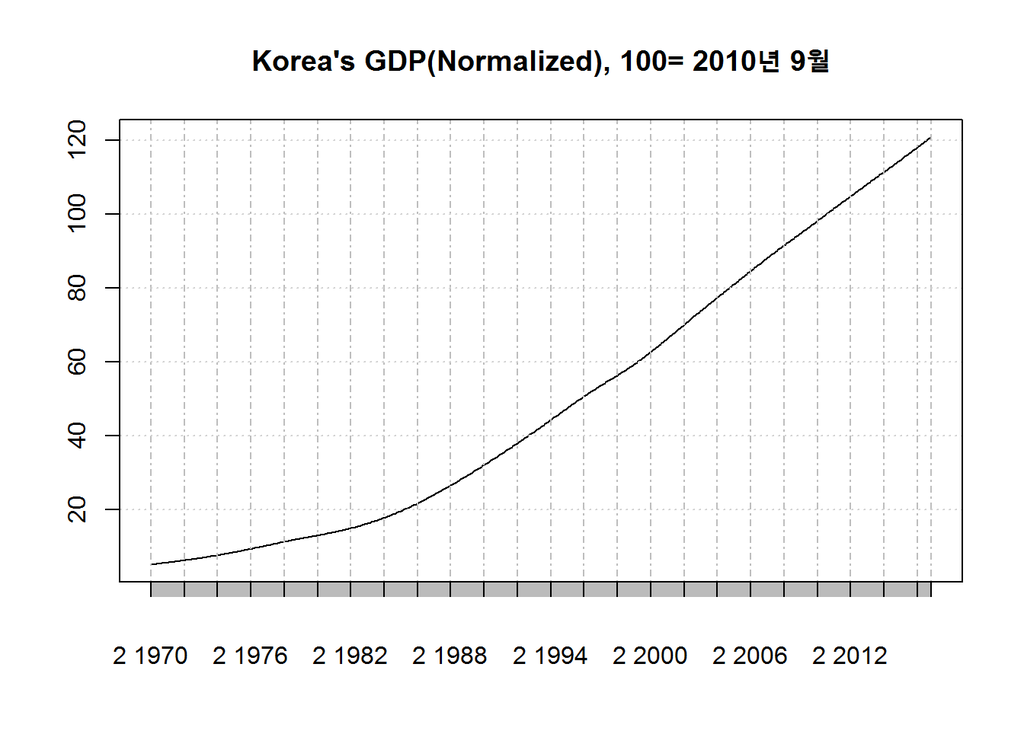

```r
library(Quandl)
library(quantmod)
#Quandl.search("GDP Korea")
KOR_GDP<-Quandl("OECD/MEI_CLI_LORSGPTD_KOR_M",type = "xts")
plot(KOR_GDP,type="l",main="Korea's GDP(Normalized), 100= 2010년 9월")
```

## The Components of Expenditure

The national income accounts divide GDP into four broad categories of spending: * Consumption (C) * Investment (I) * Government Purchases (G) * Net Exports (NX) We can write GDP as:

#### Y = C + I + G + NX

This equation is called the **national income accounts identity**

**Consumption** : goods and services bought by households

**Investment** : goods bought for future use. Investment is also divided into three subcategories: 1. Business fixed investment: purchase of new plant and equipment by firms 2. Residential investment: the purchase of new housing by households and landlords. 3. Inventory investment: the increase in firms’ inventories of goods

**Government Purchases** : goods and services bought by federal, state, and local governments.

**Net Exports** : the value of goods and services sold to other countries (export) minus value of goods and services that foreigners sell us (Imports).

## Other Measures of Income

#### Gross National Product(GNP) = GDP + Factor Payments from Abroad - Factor Payments to Abroad

GNP measures the total income earned by nationals(residents of a nation)

#### Net national Product(NNP) = GNP - Depreciation

Depreciation of capital: the amount of the economy’s stock of plants, equipment, and residential structures that wears out during the year.

#### Personal Income = National Income - Indirect Business Taxes - Corporate Profits - Social Insurance Contributions - Net Interest + Dividends + Government Transfers to Individuals + Personal Interest Income

#### Disposable Personal Income = Personal Income - Personal Tax and Nontax Payments

# Measuring the Cost of Living: The Consumer Price Index (CPI)

## The Price of a Basket of Goods

**Consumer Price Index(CPI)** turns the prices of many goods and services into a single index measuring the overall level of prices

#### CPI = $\frac{Prices of Baskets of Current Year}{Prices of Baskets of Base Year}$

**CPI is a good measure to derive inflation as well as GDP Deflator. However, genearally, CPI overstates the inflation. We need to consider that when we use CPI**

# Measuring Joblessness: The Unemployment Rate

- Employed: those who at the time of the survey worked as paid employees, worked in their own business, or worked as unpaid workers in a family member’s business.
- Unemployed: those who were not emplyed, were available for work, and had tried to find employment during the previous four weeks.
- Not in the labor force: those who fit neither of the first two categories, such as a full-time student, homemaker, or retiree.

#### Labor Force = Number of Employed + Number of Unemployed

#### Unemployment Rate = $\frac{Number of Unemployed}{Labor Force} \times 100$

#### Labor-Force Participation Rate = $\frac{Labor Force}{Adult Population} \times 100$

```r
Quandl.search("unemployment United States")
```

[output not shown]

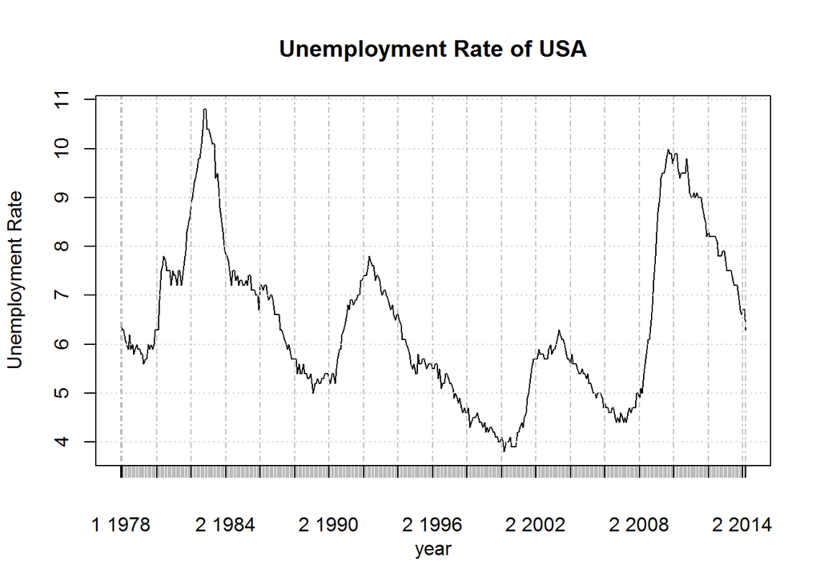

```r
UE<-Quandl("FRBC/UNEMP_ST_US",type="xts")
plot(UE,type="l",main="Unemployment Rate of USA",xlab="year",ylab="Unemployment Rate")
```

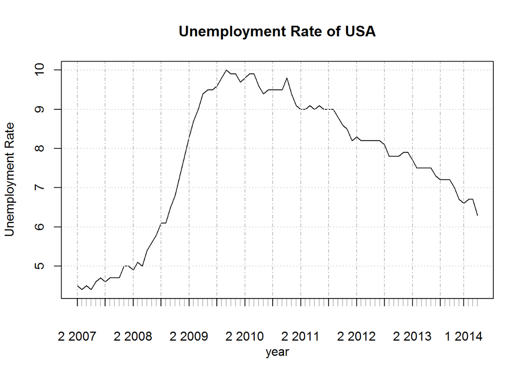

```r
plot(UE["2007::"],main="Unemployment Rate of USA",xlab="year",ylab="Unemployment Rate")
```